# 3 States of Matter; *Gas, Petrol and Cars*

## First, data collection!

An investigation into fuel prices across petrol stations in Auckland.

Observations were obtained by taking photographs of prices while travelling to and from university and work, and noting down the data in a Google form.

────── ⋆⋅☆⋅⋆ ──────

## Rain or Shine

After collating a wide sample of data, it only felt appropriate to make a collage of a few of the photos taken across the data collection period.

[figure not shown]

*(excuse the blurriness or questionable photo quality… most photos were taken while travelling)*

────── ⋆⋅☆⋅⋆ ──────

## When were we doing stakeouts?

This plot shows the frequency of recorded fuel prices by hour of the day and day of the week.

It helps identify whether data collection is consistent or clustered around specific travel times.

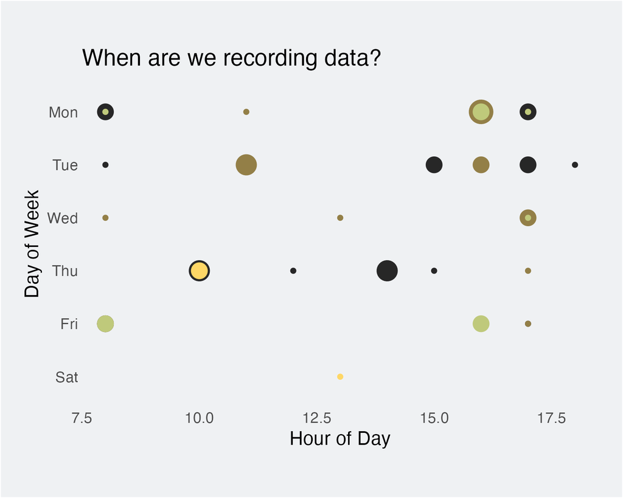

Data was recorded in military time, and a total of 59 observations were made.

As per the graph, we tended to collect more data in the evening at the start of the week, and then after in mornings across the week.

Perhaps too tired in the morning to make sense of the world?

But what about the prices?

────── ⋆⋅☆⋅⋆ ──────

## How much does petrol *really* cost?

As shown below, the prices tend to be more varied for diesel compared to standard petrol, even sometimes dropping lower than unleaded 91.

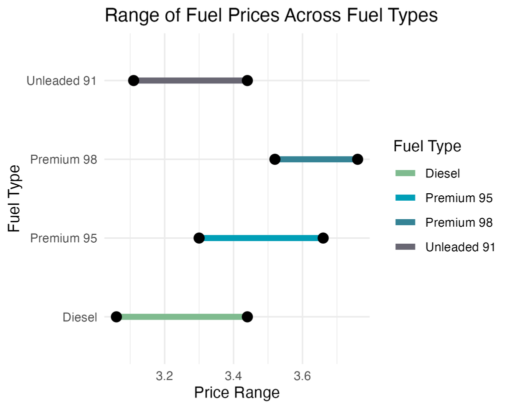

But what if we want to save money? Especially these days..what do petrol brands offer?

────── ⋆⋅☆⋅⋆ ──────

## Are memberships worth it?

This density plot compares the distribution of regular 91 fuel prices with member-discounted 91 prices.

It allows us to visually assess whether membership consistently shifts prices lower.

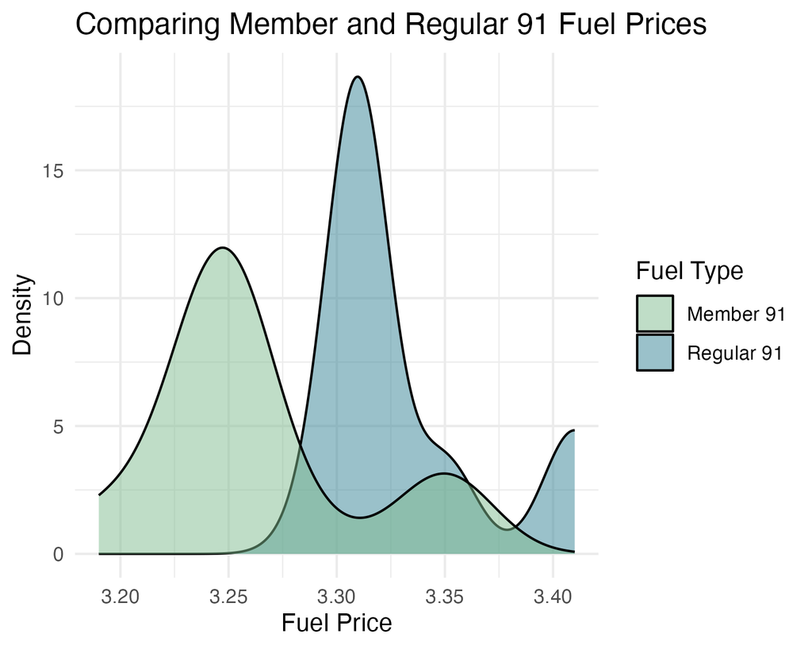

As shown, it is infact a stark contrast between member prices and standard prices for unleaded 91.

But what about specific brands? Is there anyone we should look out for?

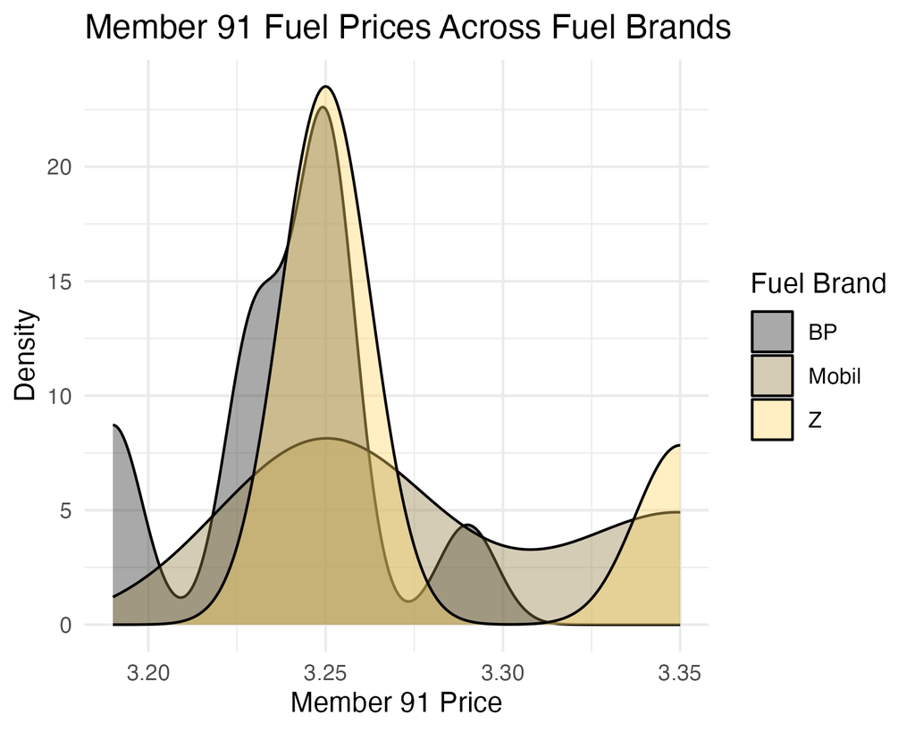

As we can see, member pricing for the brands is quite consistent, but tends to increase for Z and Mobil, whereas BP is consistently lower on average.

────── ⋆⋅☆⋅⋆ ──────

## Who’s the Petrol Popularity Queen?

Speaking of petrol brands, who tends to get the most traffic?

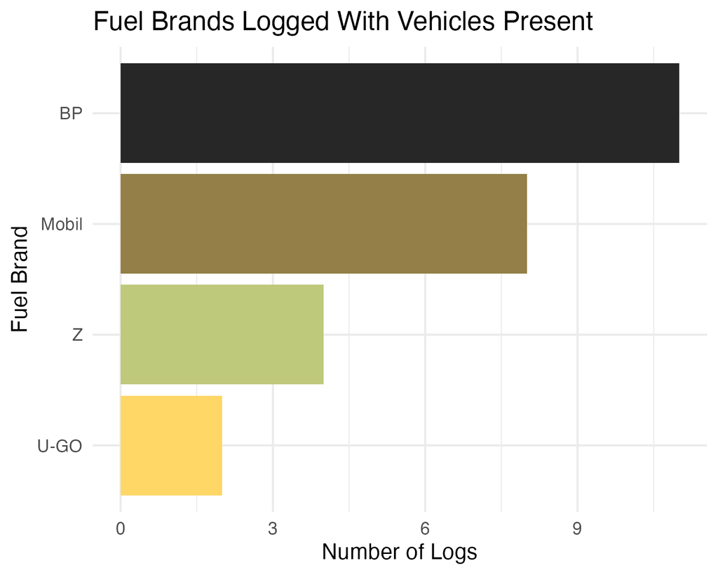

As shown, consistent with other data, BP seems to be the most favoured brand, with the highest amount of customers.

────── ⋆⋅☆⋅⋆ ──────

## At the finish line..

Through this study, we found that it is indeed beneficial to have a membership at petrol brands, specifically BP as they tend to have lower membership prices compared to other brands. Hence why they also tended to have more cars at the station compared to other brands.